# NYPD Shooting Incident Data

2022-08-14

```r
library(tidyverse)
library(lubridate)
library(dplyr)
library(ggplot2)

url_in <- "https://data.cityofnewyork.us/api/views/833y-fsy8/rows.csv?accessType=DOWNLOAD"

data <- read_csv(url_in)

data <- data %>%
  select(-c(INCIDENT_KEY, JURISDICTION_CODE, X_COORD_CD, Y_COORD_CD, Latitude, Longitude, Lon_Lat, PRECINCT, LOCATION_DESC, STATISTICAL_MURDER_FLAG, OCCUR_TIME)) %>%
  mutate(OCCUR_DATE = mdy(OCCUR_DATE))

data <- data[order(data$OCCUR_DATE),]

data
```

```
## # A tibble: 25,596 × 8
##    OCCUR_DATE BORO          PERP_AGE_G…¹ PERP_…² PERP_…³ VIC_A…⁴ VIC_SEX VIC_R…⁵
##    <date>     <chr>         <chr>        <chr>   <chr>   <chr>   <chr>   <chr>
##  1 2006-01-01 MANHATTAN     25-44        M       BLACK   25-44   M       BLACK
##  2 2006-01-01 BROOKLYN      UNKNOWN      U       UNKNOWN 18-24   M       BLACK
##  3 2006-01-01 BRONX         25-44        M       WHITE … 18-24   M       WHITE …
##  4 2006-01-01 BROOKLYN      <NA>         <NA>    <NA>    25-44   M       BLACK
##  5 2006-01-01 QUEENS        18-24        M       BLACK   18-24   M       BLACK
##  6 2006-01-01 QUEENS        18-24        M       BLACK   25-44   M       BLACK
##  7 2006-01-01 QUEENS        25-44        M       BLACK   25-44   M       BLACK
##  8 2006-01-01 BRONX         18-24        M       BLACK   <18     M       BLACK
##  9 2006-01-02 BROOKLYN      UNKNOWN      U       UNKNOWN 25-44   M       BLACK
## 10 2006-01-02 STATEN ISLAND 18-24        M       BLACK   18-24   M       BLACK
## # … with 25,586 more rows, and abbreviated variable names ¹PERP_AGE_GROUP,
## #   ²PERP_SEX, ³PERP_RACE, ⁴VIC_AGE_GROUP, ⁵VIC_RACE
## # ℹ Use `print(n = ...)` to see more rows
```

```r
summary(data)
```

```
##    OCCUR_DATE             BORO           PERP_AGE_GROUP       PERP_SEX
##  Min.   :2006-01-01   Length:25596       Length:25596       Length:25596
##  1st Qu.:2009-05-10   Class :character   Class :character   Class :character
##  Median :2012-08-26   Mode  :character   Mode  :character   Mode  :character
##  Mean   :2013-06-13
##  3rd Qu.:2017-07-01
##  Max.   :2021-12-31
##   PERP_RACE         VIC_AGE_GROUP        VIC_SEX            VIC_RACE
##  Length:25596       Length:25596       Length:25596       Length:25596
##  Class :character   Class :character   Class :character   Class :character
##  Mode  :character   Mode  :character   Mode  :character   Mode  :character
##
##
##
```

## Visualization

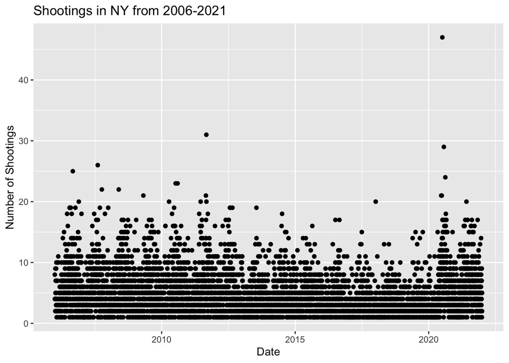

```r
df <- count(data, OCCUR_DATE)
ggplot(df, aes(x=OCCUR_DATE, y=n)) + geom_point() + ggtitle("Shootings in NY from 2006-2021") +xlab("Date") + ylab("Number of Shootings")
```

```r
linMod = lm(n~OCCUR_DATE, data = df)
summary(linMod)
```

```
##
## Call:
## lm(formula = n ~ OCCUR_DATE, data = df)
##
## Residuals:
##    Min     1Q Median     3Q    Max
## -4.480 -2.457 -0.984  1.606 42.901
##
## Coefficients:
##               Estimate Std. Error t value Pr(>|t|)
## (Intercept)  8.930e+00  4.586e-01  19.475   <2e-16 ***
## OCCUR_DATE  -2.619e-04  2.845e-05  -9.207   <2e-16 ***
## ---
## Signif. codes:  0 '***' 0.001 '**' 0.01 '*' 0.05 '.' 0.1 ' ' 1
##
## Residual standard error: 3.551 on 5407 degrees of freedom
## Multiple R-squared:  0.01543,    Adjusted R-squared:  0.01525
## F-statistic: 84.76 on 1 and 5407 DF,  p-value: < 2.2e-16
```

As can be seen above, the number of shootings in NY steadily declined (minus some outliers) for years until 2020, where it has increased again.

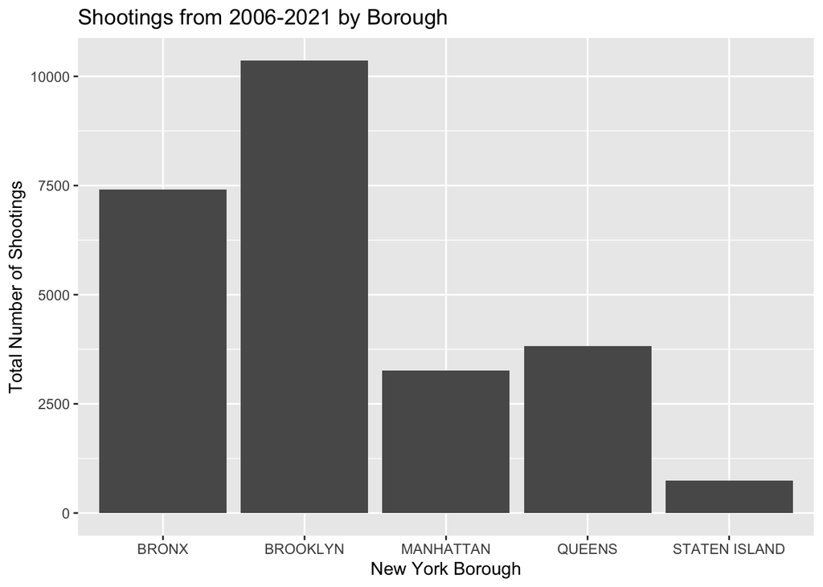

```r
dff <- count(data, BORO)
ggplot(dff, aes(x=BORO, y=n)) + geom_bar(stat="identity") + ggtitle("Shootings from 2006-2021 by Borough") + xlab("New York Borough") + ylab("Total Number of Shootings")
```

Shootings occur far more frequently in Brooklyn or the Bronx, but relatively rarely in the other boroughs.

## Conclusion

Overall, by looking at the graph and the linear model, one can see that there has been a general decrease in shootings in New York over the last decade and a half, even accounting for the uptick during 2020 and 2021. You can also see that there have been far more shootings in Brooklyn and the Bronx compared to Staten Island, Manhattan, and Queens.

There are several possible ways bias could have affected the data and the way it is presented. By only focusing on shootings, we neglect other crimes occurring in the city. Is it possible that when shootings decrease, other crimes become more likely? Or does the decrease in shootings correspond to a decrease in all crime? Another obvious way bias affects the visualization of the data is in the summary of the shootings that occur in each borough. Shootings look especially extreme in the Bronx and Brooklyn, but we are only looking at the total number of shootings per borough. We aren’t accounting for population size, levels of poverty, or other important factors. So it is possible that the differences between the boroughs and their shooting rates is not as extreme as it looks.